# Assessing affect of annofilt on E. coli annotations

Nick Waters

22 March 2018

annofilt is designed to remove dubiously annotated genes from the end of assembly contigs. After it was run on our collection of 149 soil *E. coli* and the 1193 enteric *E. coli*. Afterwards, the results were combined into a single file using the following hack:

```bash
# Make the input file from a bunch of runs
for i in annofilt_prokka_outputs/*/annofilt.log
  do
    # get the line that logs the output
    line=`cat ${i} | grep "Total from"`
    echo $i $line >> logs.logs
done
```

We read in the ugly file, and make a dataframe from the relevent columns:

```r
data <- read.table("../data/logs.logs")
file <- as.character(gsub(".*/(.*?)/annofilt.log", "\\1", data[, 1]))
contigs <- as.numeric(data[, 9])
total <- as.numeric(data[, 11])
kept <- as.numeric(data[, 13])
lost <- as.numeric(data[, 15])
wide <- data.frame(file, contigs, total, kept, lost)
str(wide)
```

```
## 'data.frame':    1342 obs. of  5 variables:
##  $ file   : Factor w/ 1342 levels "ESC_AA7745AA",..: 1 2 3 4 5 6 7 8 9 10 ...
##  $ contigs: num  109 47 70 429 178 85 128 133 131 133 ...
##  $ total  : num  5178 4776 4432 5455 4619 ...
##  $ kept   : num  5121 4761 4402 5268 4550 ...
##  $ lost   : num  57 15 30 187 69 32 69 54 60 61 ...
```

Now, lets calculate the genes searched (one from each end of each contig), the genes retained, and the percent retained. Also, for fun, let’s mark which ones are our soil isolates and which are from Enterobase.

```r
wide <- wide %>%
  mutate(pool = as.factor(ifelse(grepl("Lys\\d*", file), "Soil", "Enterobase"))) %>%
  group_by(file) %>%
  mutate(genes_searched = contigs * 2,
         genes_searched_kept = genes_searched - lost,
         percent_rejected = 1 - (genes_searched_kept / genes_searched)
         ) %>%
  as.data.frame()

# and lets make a within_group "id" to identify them later
wide <- wide %>%
  group_by(pool) %>%
  # get the order; this will help us later as an x axis
  mutate(wgid=as.numeric(factor(1:n(), levels = order(genes_searched)))) %>%
  as.data.frame()

# wide$wgid <- factor(wide$wgid)

tall <- melt(
  wide, id.vars = c("file", "pool", "wgid"),
  variable.name = "category",
    value.name = "count")
```

Lets look at a histogram of the total vs retained genes:

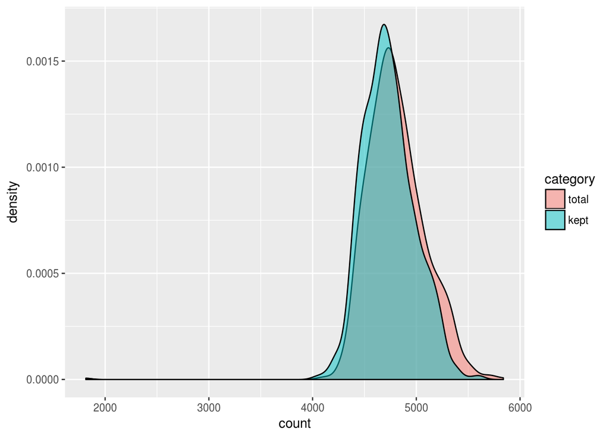

```r
(genehist <- ggplot(tall[tall$category %in% c("total", "kept"),], aes(fill=category)) +
  geom_density(aes(x=count), position="identity", alpha=.5 ))
```

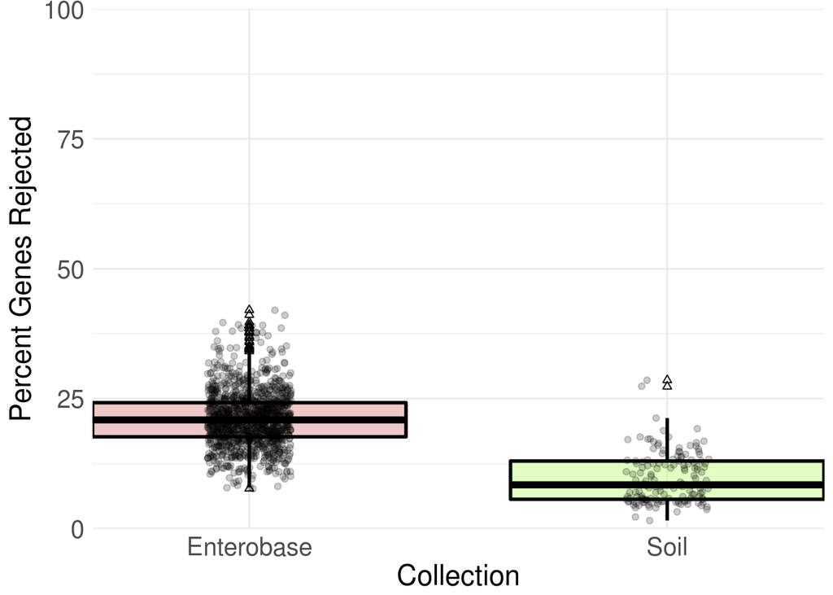

```r
# plotting the percent genes that are rejected by annofilt
(boxplots <- ggplot(f[f$category=="percent_rejected", ],
       aes(x=pool, y=count * 100, group=pool, fill=pool)) +
  geom_boxplot(lwd=1, color="black", outlier.shape = 2) +
  geom_jitter(width=.1, height=.1, alpha=.2) +
  scale_fill_manual(values=c("#d2797966", "#b3ff6666"), guide=F) +
  scale_x_discrete(expand = c(0, 0)) +
  scale_y_continuous(limit=c(0, 100), expand = c(0, 0)) +
  theme_minimal()+
  theme(axis.text = element_text(size=15),
        axis.title = element_text(size=17)) +
  labs(
    # title="Percent genes rejected by annofilt",
     y="Percent Genes Rejected",
     x="Collection"))
```

And here is a visual of how any genes are getting removed in realtion to the total (in grey).

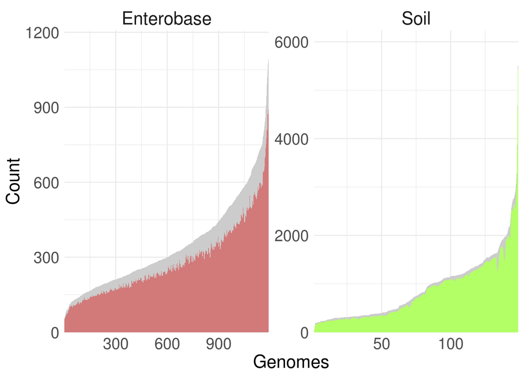

```r
(fillplot <- ggplot(wide,
       aes(x=wgid, fill=pool)) +
  facet_wrap(~pool, scales="free") +
  geom_area(aes(y=genes_searched), fill="grey80") +
  # geom_line(aes(y=genes_searched), color="grey20", size=1) +
  geom_area(aes(y=genes_searched_kept)) +
  scale_fill_manual(values=c("#d27979", "#b3ff66"), guide=F) +
  theme_minimal()+
  theme(axis.text = element_text(size=15),
        axis.title = element_text(size=17),
        strip.text = element_text(size=17)) +
  scale_x_continuous(expand = c(0, 0)) +
  scale_y_continuous(expand = c(0, 0)) +
  labs(x="Genomes", y="Count"))
```

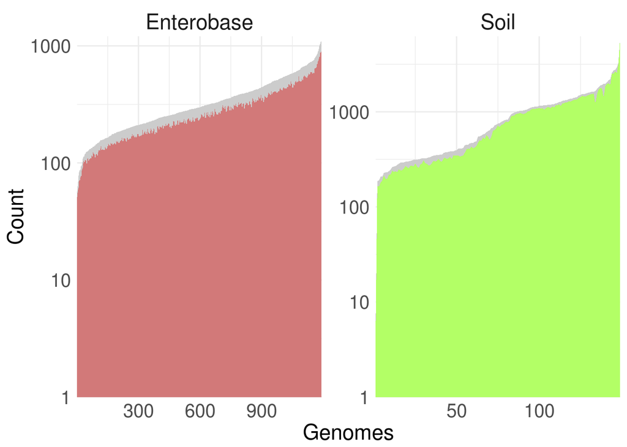

```r
(fillplotlog <- ggplot(wide,
       aes(x=wgid, fill=pool)) +
  facet_wrap(~pool, scales="free") +
  geom_area(aes(y=genes_searched), fill="grey80") +
  # geom_line(aes(y=genes_searched), color="grey20", size=1) +
  geom_area(aes(y=genes_searched_kept)) +
  scale_fill_manual(values=c("#d27979", "#b3ff66"), guide=F) +
  theme_minimal()+
  theme(axis.text = element_text(size=15),
        axis.title = element_text(size=17),
        strip.text = element_text(size=17)) +
  scale_x_continuous(expand = c(0, 0)) +
  scale_y_log10(expand = c(0, 0)) +
  labs(x="Genomes", y="Count"))
```

And lets write out the plots to the file:

```r
height=4
width=6
dest=file.path("..", "results", "")
pdf(file = paste0(dest, "hist.pdf"), width = width, height=height)
genehist
dev.off()
```

```r
pdf(file = paste0(dest, "box.pdf"), width = width, height=height)
boxplots
dev.off()
```

```r
pdf(file = paste0(dest, "fillplot.pdf"), width = width, height=height)
fillplot
dev.off()
```

```r
pdf(file = paste0(dest, "fillplotlog.pdf"), width = width, height=height)
fillplotlog
dev.off()
```